# Predikcija odustajanja učenika

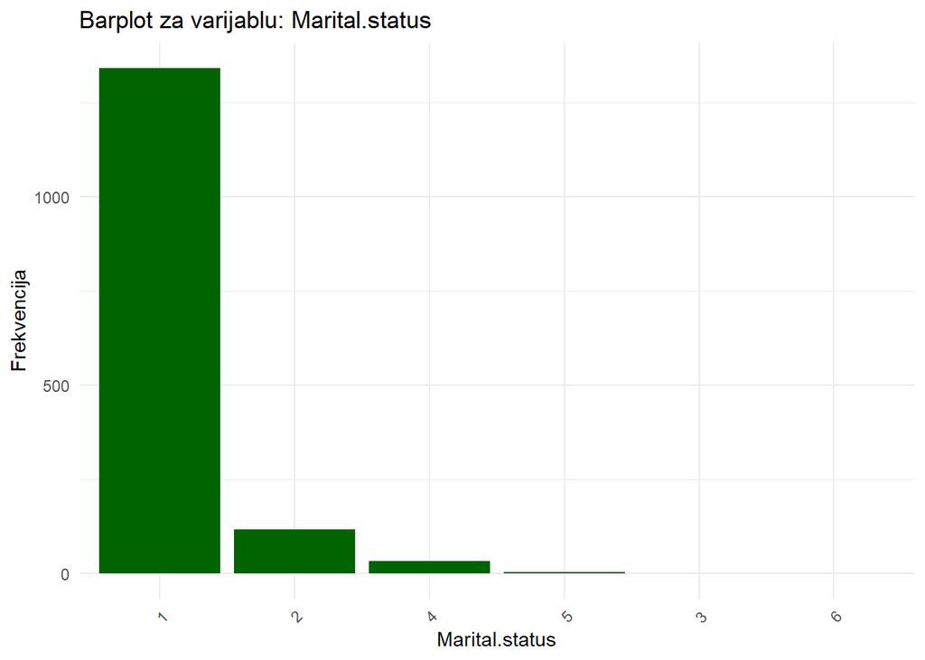

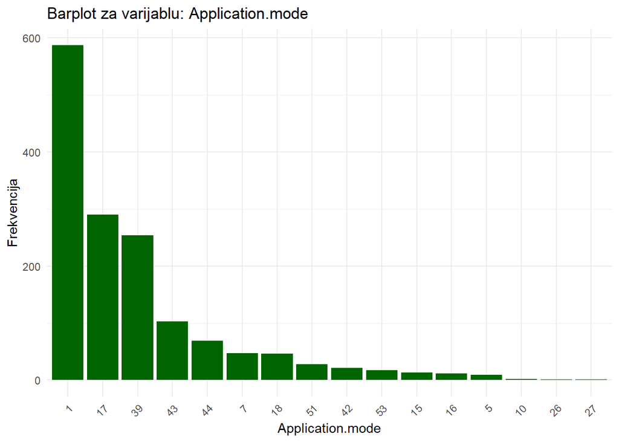

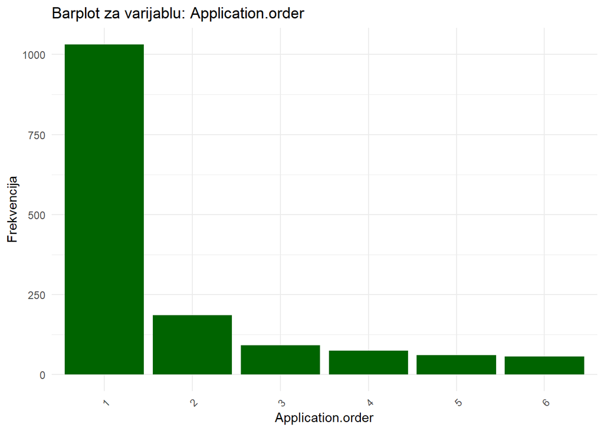

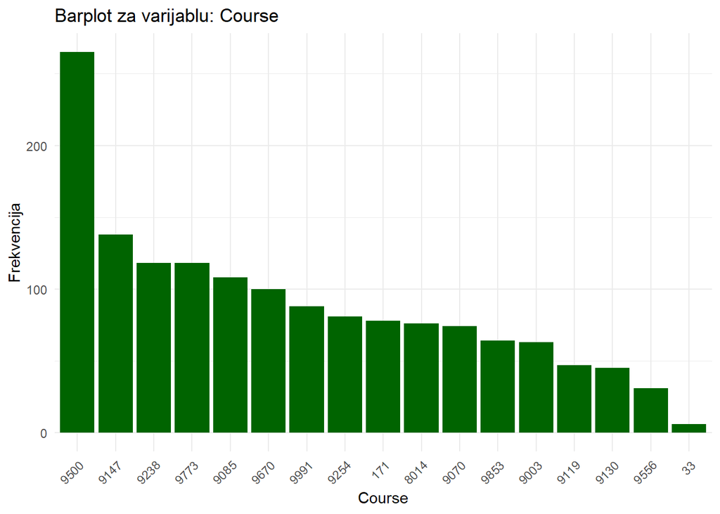

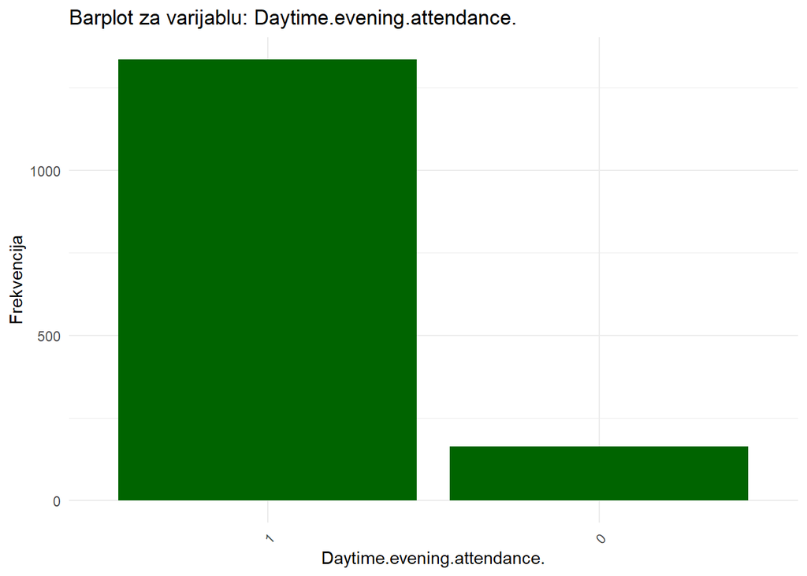

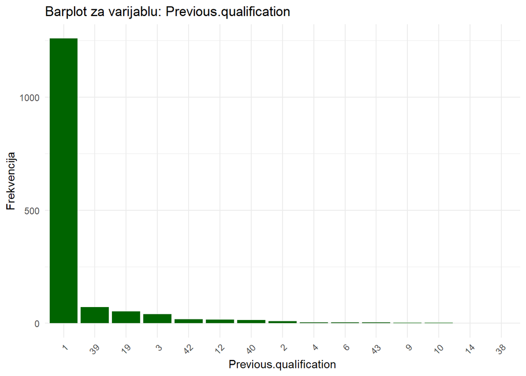

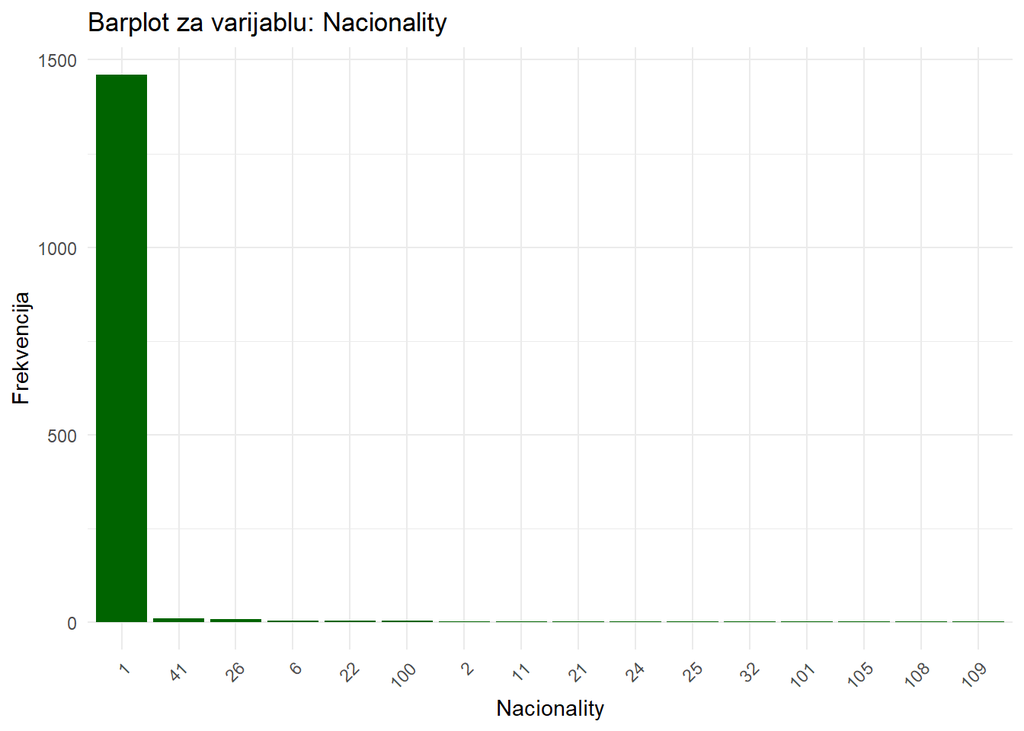

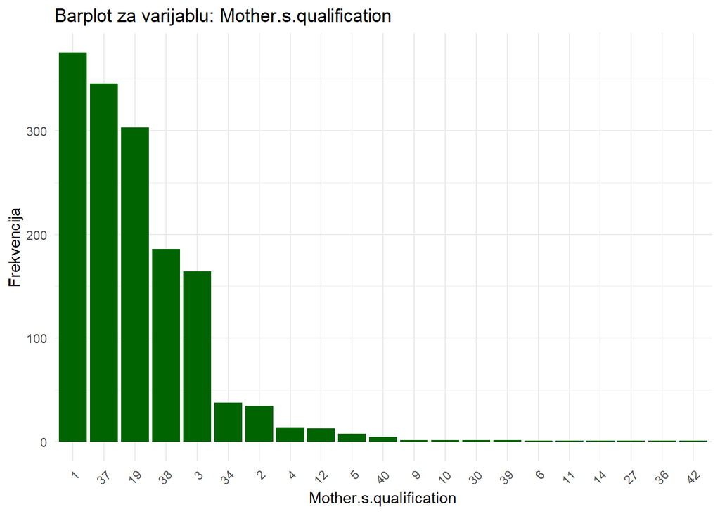

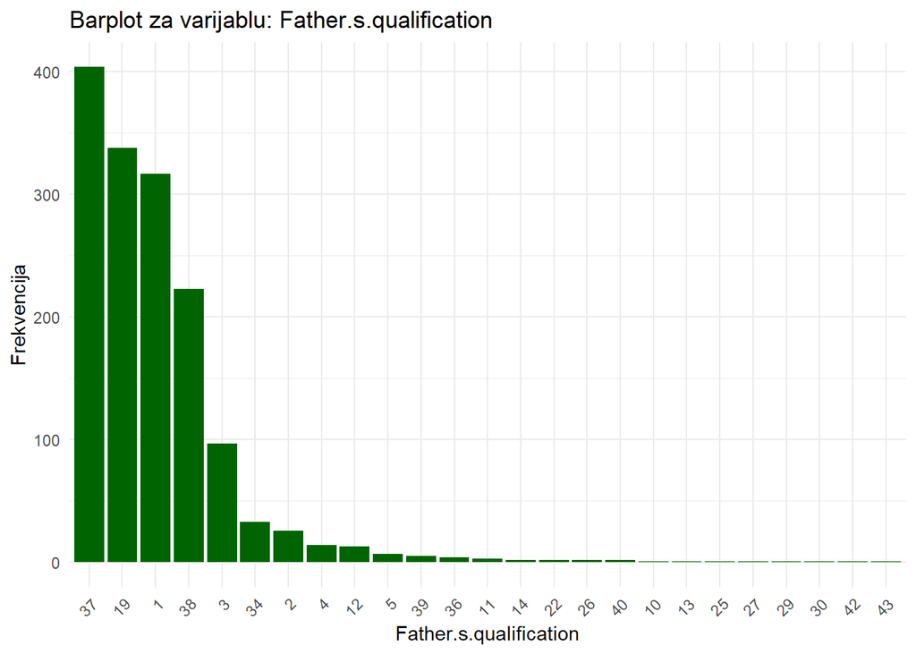

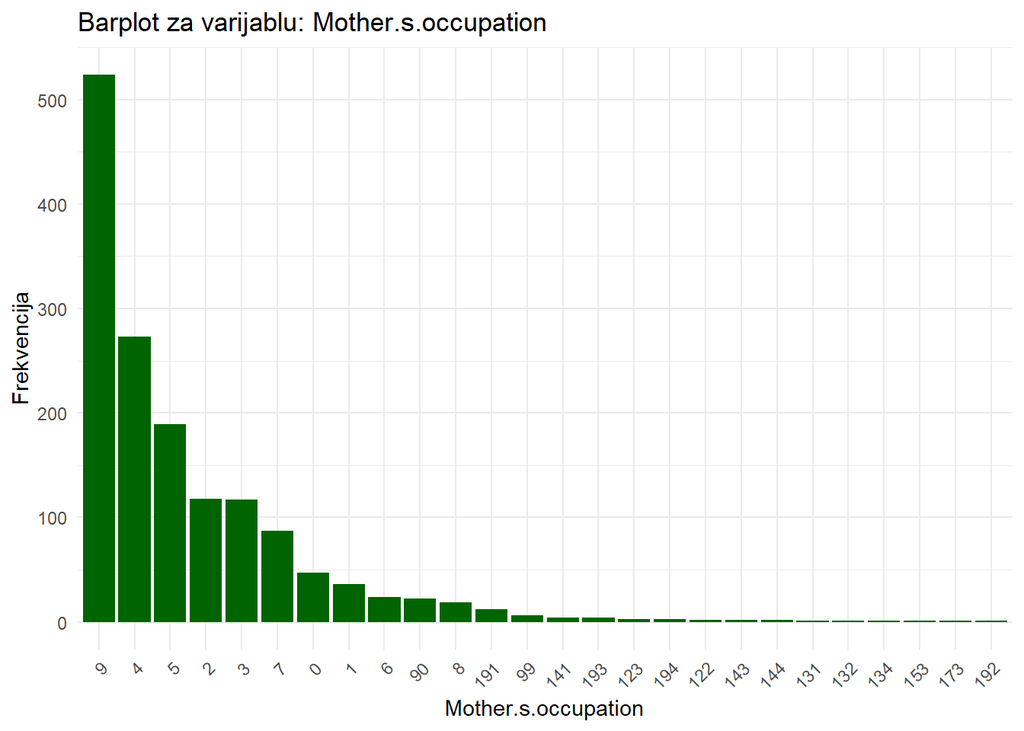

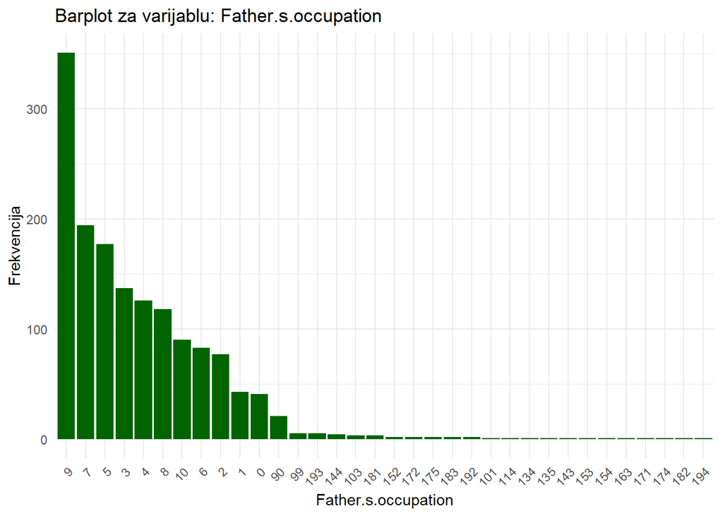

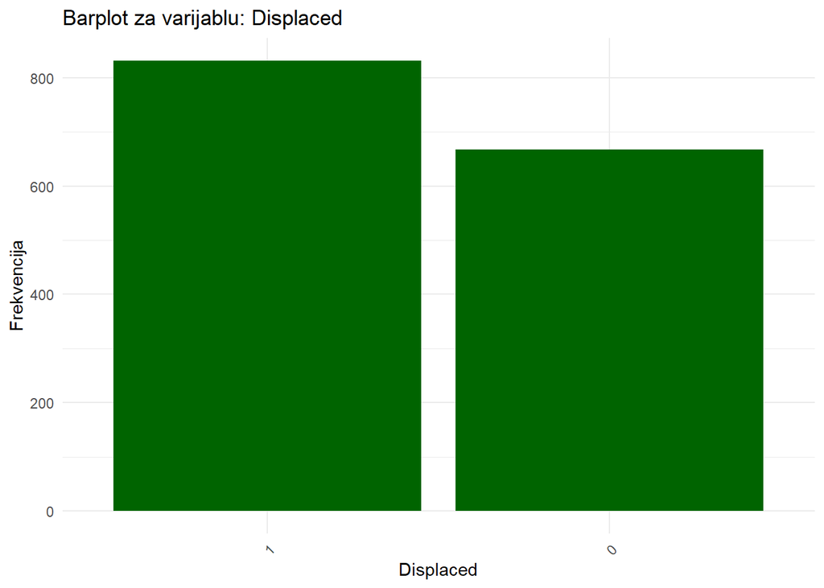

[7 more figures not shown]

```r
# Grafički prikaz – stupčasti dijagram za svaku kvalitativnu varijablu:
library(ggplot2)

for (var in kvalitativne) {
  plot_data <- as.data.frame(table(df_sample[[var]]))
  colnames(plot_data) <- c("Kategorija", "Frekvencija")

  print(
    ggplot(plot_data, aes(x = reorder(Kategorija, -Frekvencija), y = Frekvencija)) +
      geom_bar(stat = "identity", fill = "darkgreen") +
      labs(title = paste("Barplot za varijablu:", var), x = var, y = "Frekvencija") +
      theme_minimal() +
      theme(axis.text.x = element_text(angle = 45, hjust = 1))
  )
}
```

Kvalitativne varijable analizirane su pomoću frekvencijskih distribucija i moda / najčešće vrijednosti. Za svaku varijablu izračunata je učestalost pojavljivanja svih kategorija, a najfrekventnija vrijednost definirana je kao mod. Vizualizacija je izvedena pomoću stupčastih dijagrama, gdje se jasno uočavaju dominantne kategorije.

## Odnos između numeričkih varijabli

```r
#install.packages("corrplot")
#install.packages("GGally")
#install.packages("dplyr")
#install.packages("reshape2")

library(corrplot)
library(GGally)
library(dplyr)
library(reshape2)
```

### Korelacijska matrica numeričkih varijabli:

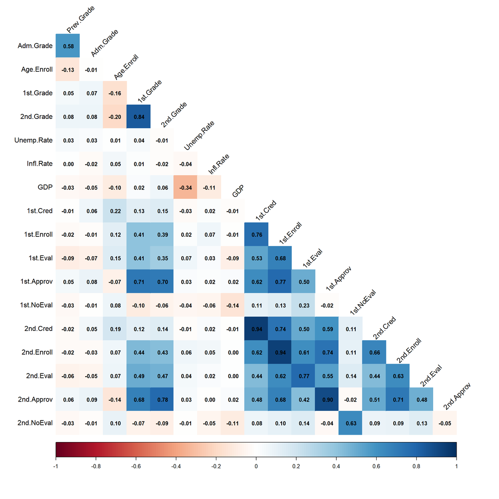

```r
# Skraćeni nazivi (ručno prilagođeni za preglednost)
kratki_nazivi <- c(
  "Prev.Grade", "Adm.Grade", "Age.Enroll",
  "1st.Grade", "2nd.Grade", "Unemp.Rate", "Infl.Rate", "GDP",
  "1st.Cred", "1st.Enroll", "1st.Eval", "1st.Approv", "1st.NoEval",
  "2nd.Cred", "2nd.Enroll", "2nd.Eval", "2nd.Approv", "2nd.NoEval"
)

# Priprema podatkaka i korelacijske matrice
df_kv <- df_sample[, kvantitativne]
colnames(df_kv) <- kratki_nazivi

korelacija <- cor(df_kv, use = "complete.obs")

# Prikaz čitke matrice
library(corrplot)
corrplot(korelacija, method = "color", type = "lower",
         tl.col = "black", tl.srt = 45,
         addCoef.col = "black", number.cex = 0.8, diag = FALSE)
```

```r
korelacija <- cor(df_kv, use = "complete.obs")

# Pretvorba korelacijske matrice u long-format tablicu
library(reshape2)
korelacija_long <- melt(korelacija)
colnames(korelacija_long) <- c("Var1", "Var2", "Correlation")

# Filtriraj samo različite parove (izbaci duplikate i dijagonalu)
korelacija_long <- korelacija_long[korelacija_long$Var1 != korelacija_long$Var2, ]
korelacija_long <- korelacija_long[!duplicated(apply(korelacija_long[,1:2], 1, paste, collapse = "_")), ]

# Prikaži jake pozitivne korelacije (>= 0.7)
korelacija_jaka_poz <- korelacija_long %>%
  filter(Correlation >= 0.7)

# Prikaži jake negativne korelacije (<= -0.3)
korelacija_jaka_neg <- korelacija_long %>%
  filter(Correlation <= -0.3)

# Ispiši rezultate
korelacija_jaka_poz
```

| Var1 | Var2 | Correlation |
| --- | --- | --- |
| 2nd.Grade | 1st.Grade | 0.8370181 |
| 1st.Approv | 1st.Grade | 0.7102950 |
| 1st.Grade | 2nd.Grade | 0.8370181 |
| 1st.Approv | 2nd.Grade | 0.7018274 |
| 2nd.Approv | 2nd.Grade | 0.7765891 |
| 1st.Enroll | 1st.Cred | 0.7587230 |
| 2nd.Cred | 1st.Cred | 0.9428601 |
| 1st.Cred | 1st.Enroll | 0.7587230 |
| 1st.Approv | 1st.Enroll | 0.7708458 |
| 2nd.Cred | 1st.Enroll | 0.7356490 |

[output cut: 16 more lines]

```r
korelacija_jaka_neg
```

| Var1 | Var2 | Correlation |
| --- | --- | --- |
| GDP | Unemp.Rate | -0.3375486 |
| Unemp.Rate | GDP | -0.3375486 |

Plava boja označava pozitivnu korelaciju, dok crvena negativnu. Što je korelacija bliža nuli to je više bijela. Slijede neka od tumačenja s grafa:

[output not shown]

1. Povezanost ocjena i prolaznosti

| Varijabla 1 | Varijabla 2 | Korelacija | Tumačenje |
| --- | --- | --- | --- |
| `1st.Grade` | `2nd.Grade` | **0.837** | Studenti s dobrim ocjenama u 1. semestru imaju sličan uspjeh i u 2. semestru |
| `1st.Grade` | `1st.Approv` | **0.710** | Što je više predmeta položeno viši je prosjek |
| `2nd.Grade` | `1st.Approv` | **0.702** | Raniji uspjeh povezan je s kasnijim ocjenama |
| `2nd.Grade` | `2nd.Approv` | **0.777** | Povezanost položenih predmeta i ocjene u 2. semestru |

2. Upisanost i priznavanje kolegija

| Varijabla 1 | Varijabla 2 | Korelacija | Tumačenje |
| --- | --- | --- | --- |
| `1st.Enroll` | `1st.Cred` | **0.759** | Više prijavljenih predmeta rezultira više priznatih predmeta |
| `2nd.Cred` | `1st.Cred` | **0.943** | Priznavanja u 1. i 2. semestru visoko povezana |
| `1st.Cred` | `2nd.Cred` | **0.943** | Broj ocijenjenih predmeta u 1. semestru se nastavlja i u drugom semestru |
| `2nd.Enroll` | `1st.Enroll` | **0.940** | Broj prijavljenih predmeta stabilan kroz semestre |

3. Evaluacije i prolaznosti

| Varijabla 1 | Varijabla 2 | Korelacija | Tumačenje |
| --- | --- | --- | --- |
| `1st.Eval` | `2nd.Eval` | **0.772** | Više evaluacija u 1. semestru → više i u 2. |
| `2nd.Approv` | `1st.Approv` | **0.900** | Broj položenih kolegija vrlo sličan kroz semestre |

Analiza Pearsonovih koeficijenata korelacije pokazala je izuzetno jake pozitivne veze između varijabli koje opisuju akademsku izvedbu. Navedeno ukazuje na dosljedan obrazac ponašanja i uspjeha studenata kroz vrijeme. Takvi odnosi sugeriraju da se akademska uspješnost može predvidjeti i modelirati uz relativno mali broj pouzdanih indikatora, budući da postoji visoka međuovisnost među njima.

### Dijagrami raspršenja

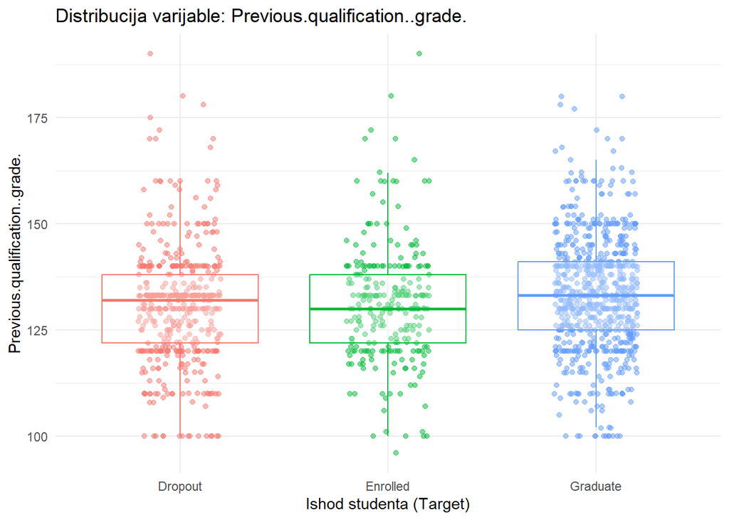

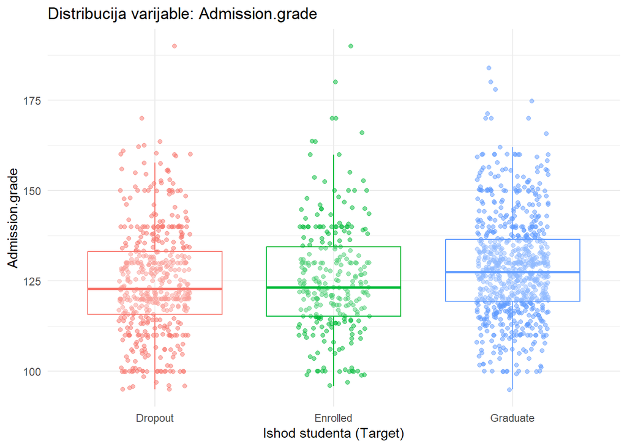

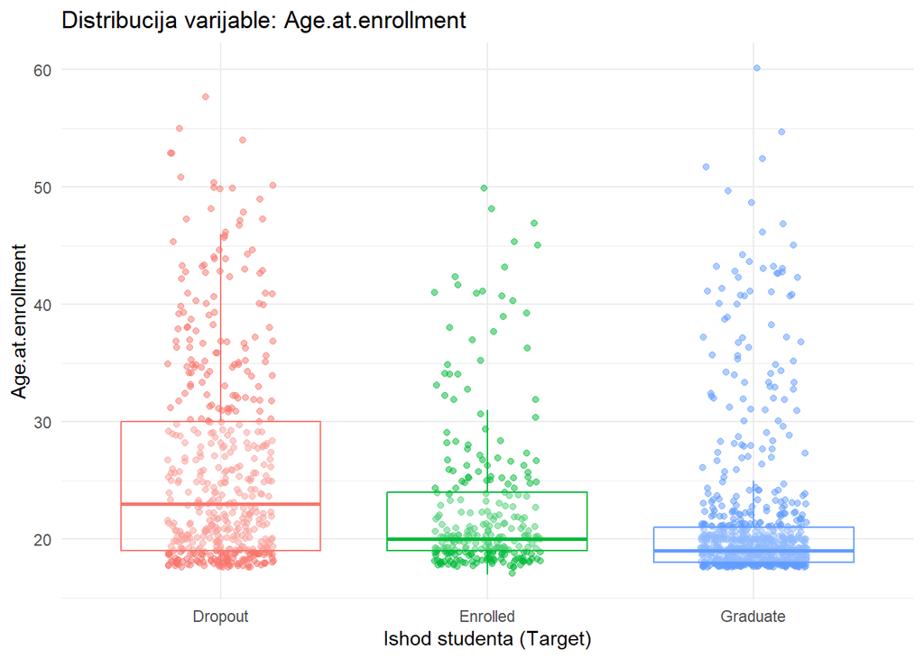

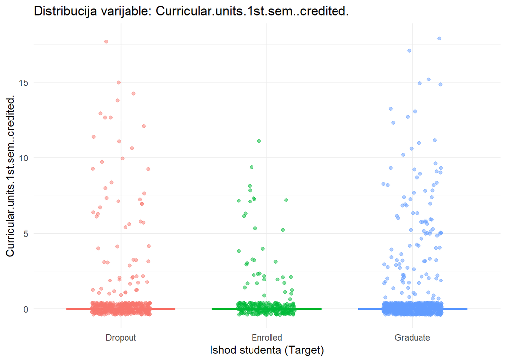

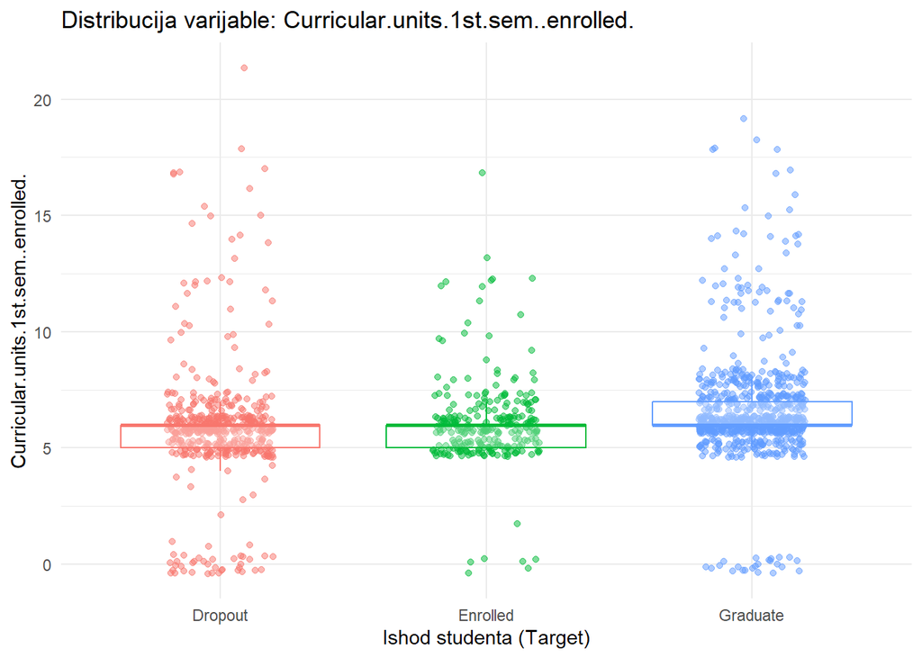

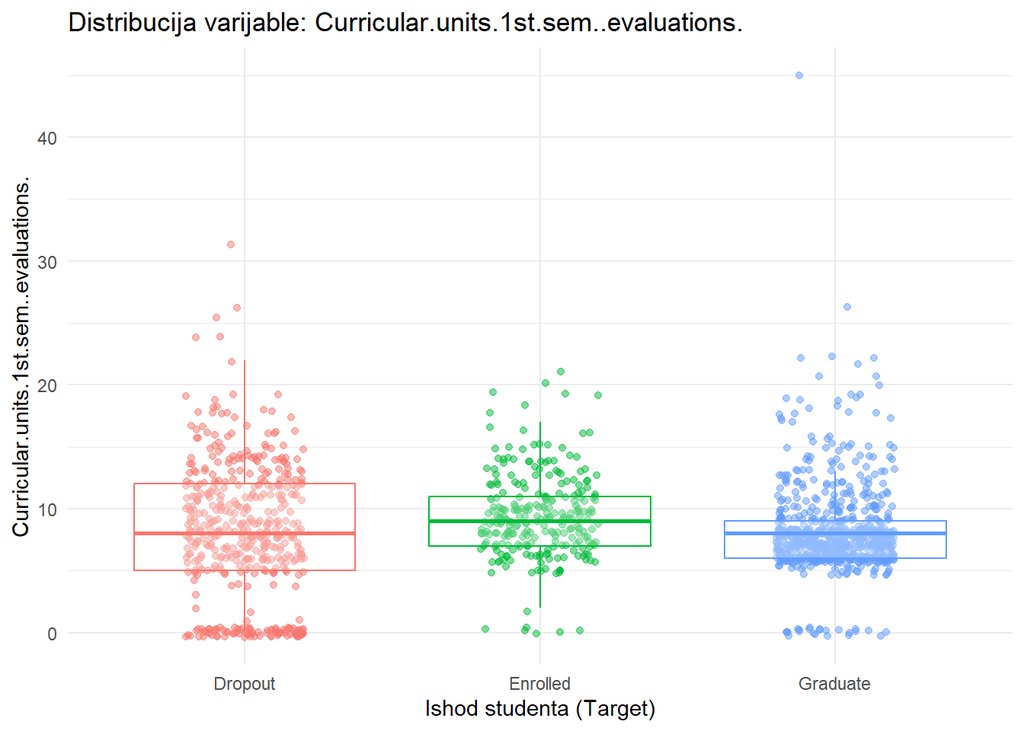

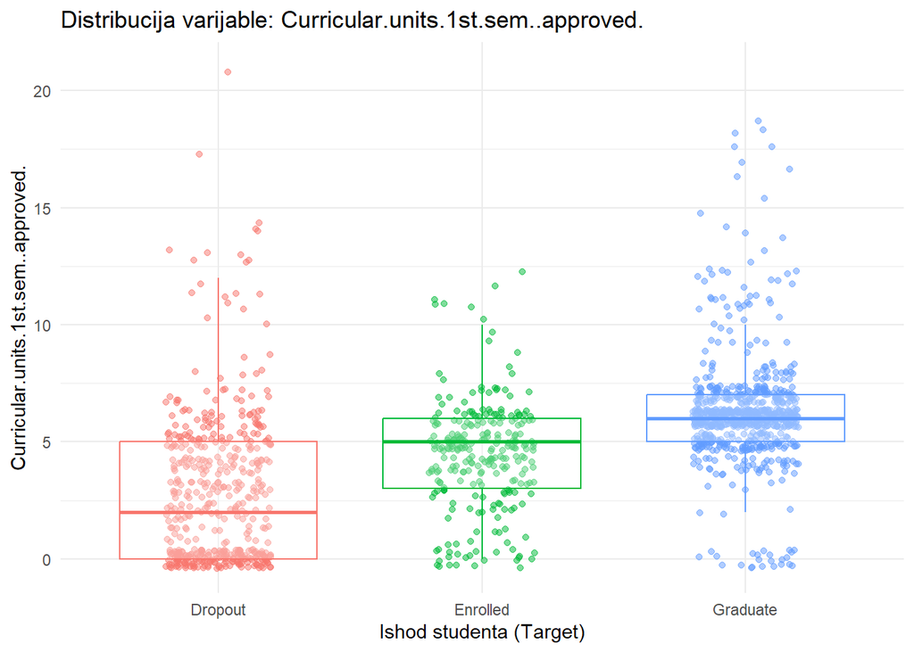

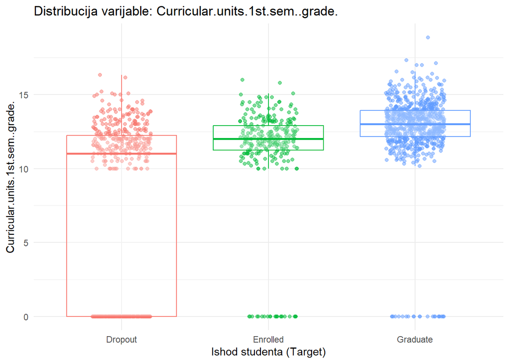

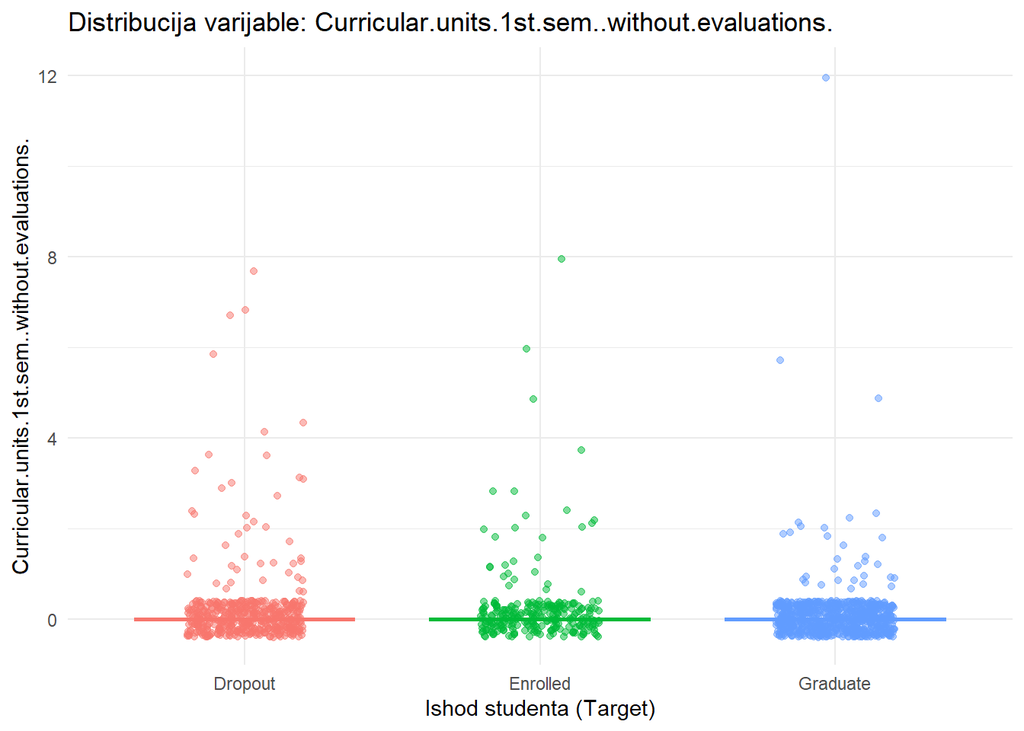

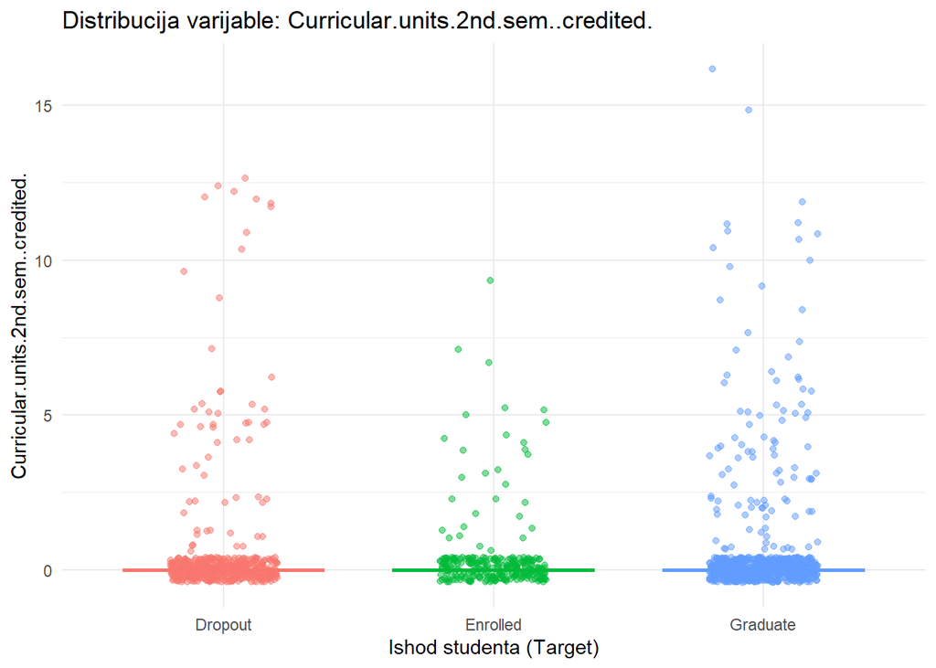

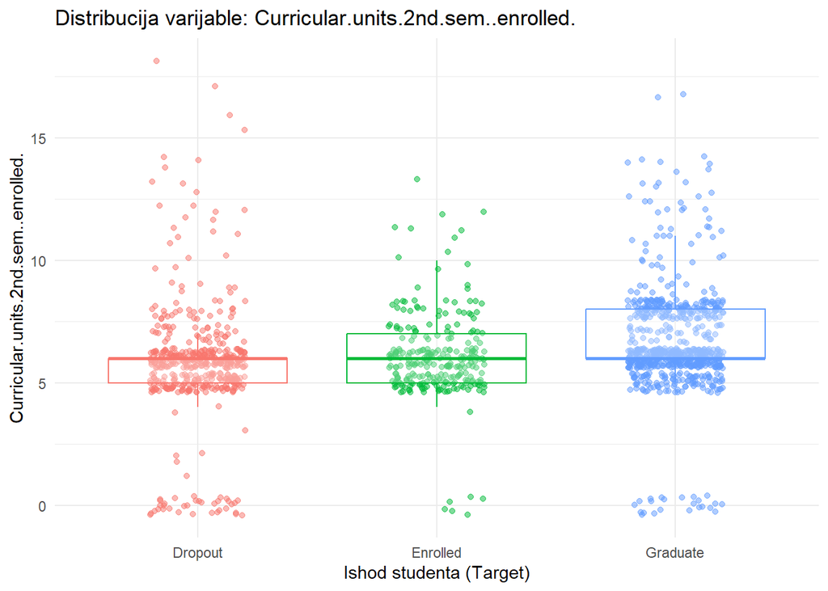

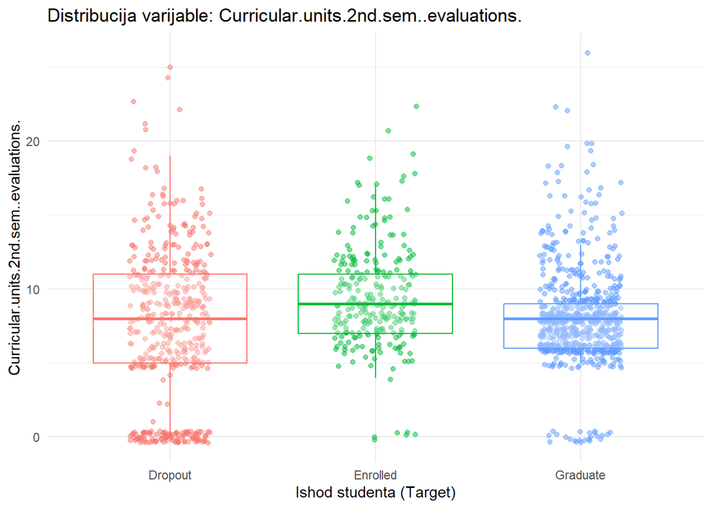

[6 more figures not shown]

```r
library(ggplot2)
library(dplyr)

kvantitativne <- df_sample %>% select(where(is.numeric)) %>% colnames()

df_num <- df_sample[, c(kvantitativne, "Target")]

df_num$Target <- as.factor(df_num$Target)

for (var in kvantitativne) {
  p <- ggplot(df_num, aes_string(x = "Target", y = var, color = "Target")) +
    geom_jitter(width = 0.2, alpha = 0.5) +
    geom_boxplot(alpha = 0.3, outlier.shape = NA) +
    theme_minimal() +
    labs(title = paste("Distribucija varijable:", var),
         x = "Ishod studenta (Target)",
         y = var) +
    theme(legend.position = "none")

  print(p)
}
```

Za svaku numeričku varijablu izrađen je scatterplot u odnosu na ishod studija (Target). Grafički prikazi ukazuju na razlike u distribuciji vrijednosti između studenata koji su diplomirali, odustali ili još studiraju.

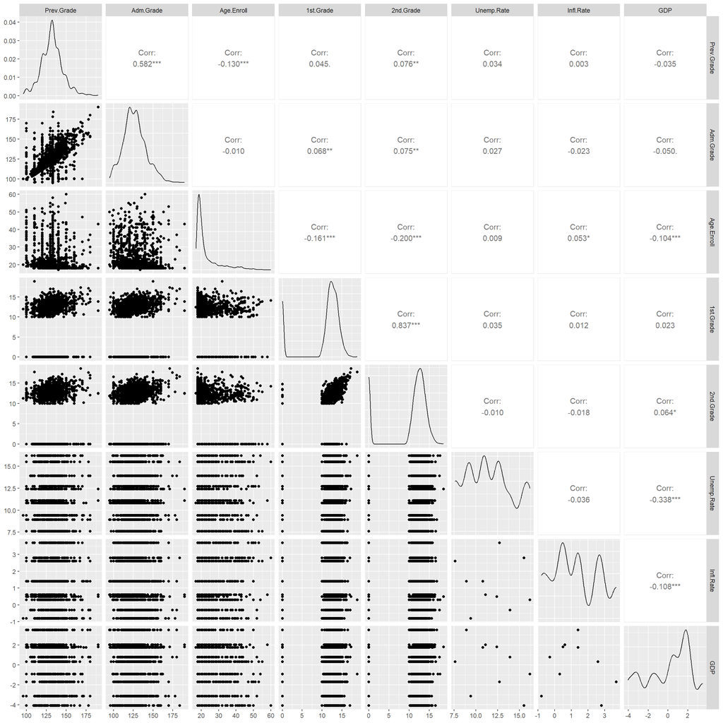

```r
# manji podskup radi preglednosti (npr. 6 varijabli)
colnames(df_kv) <- kratki_nazivi
GGally::ggpairs(df_kv[, 1:8])
```

```r
#GGally::ggpairs(df_kv)
```

Zbog duljine naziva varijabli, korišteni su skraćeni identifikatori u prikazu korelacijske matrice i dijagrama raspršenja. Time se osigurava bolja preglednost i razumljivost rezultata bez gubitka značenja.

Korelacijska matrica pokazuje Pearsonove koeficijente linearne povezanosti između svih kvantitativnih varijabli. Koeficijenti se kreću između -1 i 1, gdje:

vrijednosti blizu +1 označavaju jaku pozitivnu korelaciju,

vrijednosti blizu -1 označavaju jaku negativnu korelaciju,

vrijednosti oko 0 ukazuju na slab ili nepostojeći linearni odnos.

Dijagrami raspršenja dodatno ilustriraju linearnost i eventualne nelinearne obrasce među varijablama.

## Provjera nedostajućih vrijednosti

```r
# Ukupan broj NA po varijabli
colSums(is.na(df_sample))
```

```
##                                 Marital.status
##                                              0
##                               Application.mode
##                                              0
##                              Application.order
##                                              0
##                                         Course
##                                              0
##                    Daytime.evening.attendance.
##                                              0
##                         Previous.qualification
##                                              0
##                 Previous.qualification..grade.
##                                              0
##                                    Nacionality
##                                              0
##                         Mother.s.qualification
##                                              0
##                         Father.s.qualification
##                                              0
##                            Mother.s.occupation
##                                              0
##                            Father.s.occupation
##                                              0
##                                Admission.grade
##                                              0
##                                      Displaced
##                                              0
##                      Educational.special.needs
##                                              0
##                                         Debtor
##                                              0
##                        Tuition.fees.up.to.date
##                                              0
##                                         Gender
##                                              0
##                             Scholarship.holder
##                                              0
##                              Age.at.enrollment
##                                              0
```

[output cut: 19 more lines]

```
##                                              0
##            Curricular.units.2nd.sem..approved.
##                                              0
##               Curricular.units.2nd.sem..grade.
##                                              0
## Curricular.units.2nd.sem..without.evaluations.
##                                              0
##                              Unemployment.rate
##                                              0
##                                 Inflation.rate
##                                              0
##                                            GDP
##                                              0
##                                         Target
##                                              0
```

```r
# Postotak NA po varijabli
na_pct <- colMeans(is.na(df_sample)) * 100
na_pct[na_pct > 0]
```

```
## named numeric(0)
```

## Provjera dupliciranih zapisa

```r
# Broj potpuno identičnih redaka
#sum(duplicated(df_sample))

# Ispis prvih nekoliko duplikata, ako postoje
#df_sample[duplicated(df_sample), ][1:5, ]
```

## Provjera ekstremnih vrijednosti (Outliers)

```r
# Definiranje outliera po IQR
detect_outliers_iqr <- function(x) {
  Q1 <- quantile(x, 0.25, na.rm = TRUE)
  Q3 <- quantile(x, 0.75, na.rm = TRUE)
  IQR <- Q3 - Q1
  (x < (Q1 - 1.5 * IQR)) | (x > (Q3 + 1.5 * IQR))
}

# Primjena na sve kvantitativne varijable
outlier_summary <- sapply(df_sample[ , kvantitativne], function(col) sum(detect_outliers_iqr(col)))
outlier_summary[outlier_summary > 0]
```

```
##                 Previous.qualification..grade.
##                                             27
##                                Admission.grade
##                                             20
##                              Age.at.enrollment
##                                            199
##            Curricular.units.1st.sem..credited.
##                                            204
##            Curricular.units.1st.sem..enrolled.
##                                            157
##         Curricular.units.1st.sem..evaluations.
##                                             56
##            Curricular.units.1st.sem..approved.
##                                             66
##               Curricular.units.1st.sem..grade.
##                                            237
## Curricular.units.1st.sem..without.evaluations.
##                                            101
##            Curricular.units.2nd.sem..credited.
##                                            188
##            Curricular.units.2nd.sem..enrolled.
##                                            131
##         Curricular.units.2nd.sem..evaluations.
##                                             40
##            Curricular.units.2nd.sem..approved.
##                                             11
##               Curricular.units.2nd.sem..grade.
##                                            290
## Curricular.units.2nd.sem..without.evaluations.
##                                             94
```

Na sljedećim boxplotovima crveni krugovi označavaju identificirane ekstremne vrijednosti. Vizualizacija je ograničena samo na one varijable koje imaju barem jedan outlier.

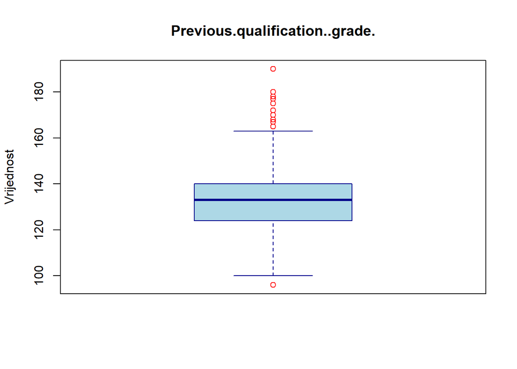

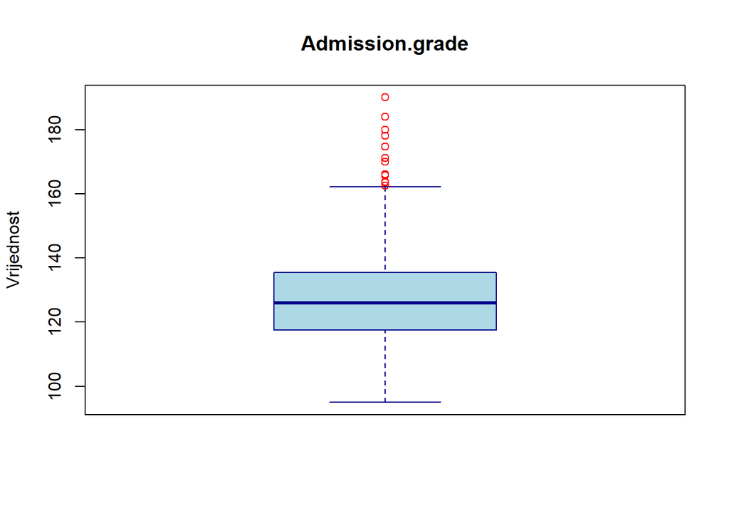

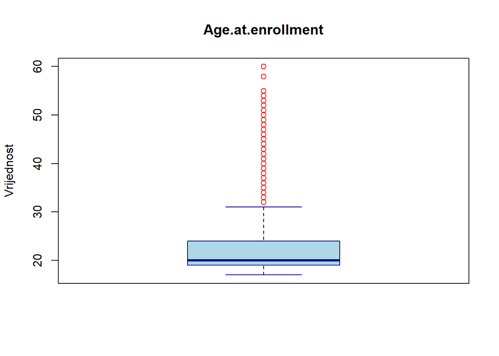

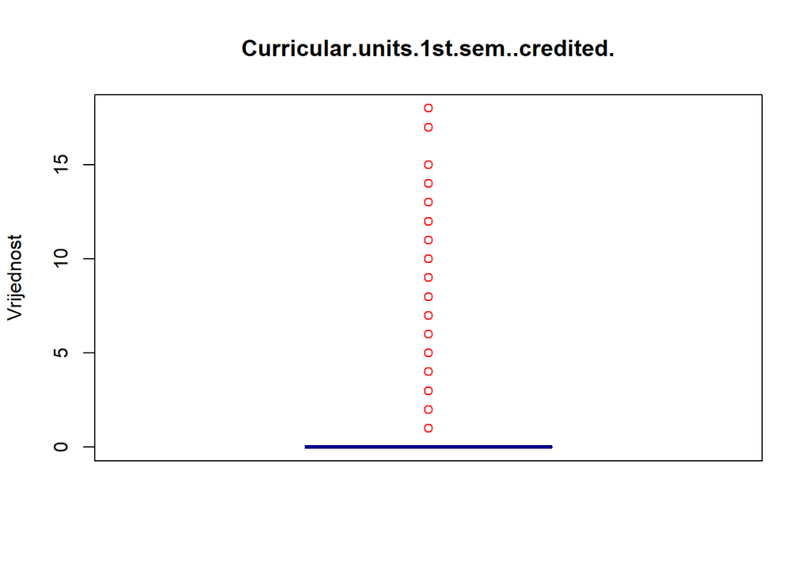

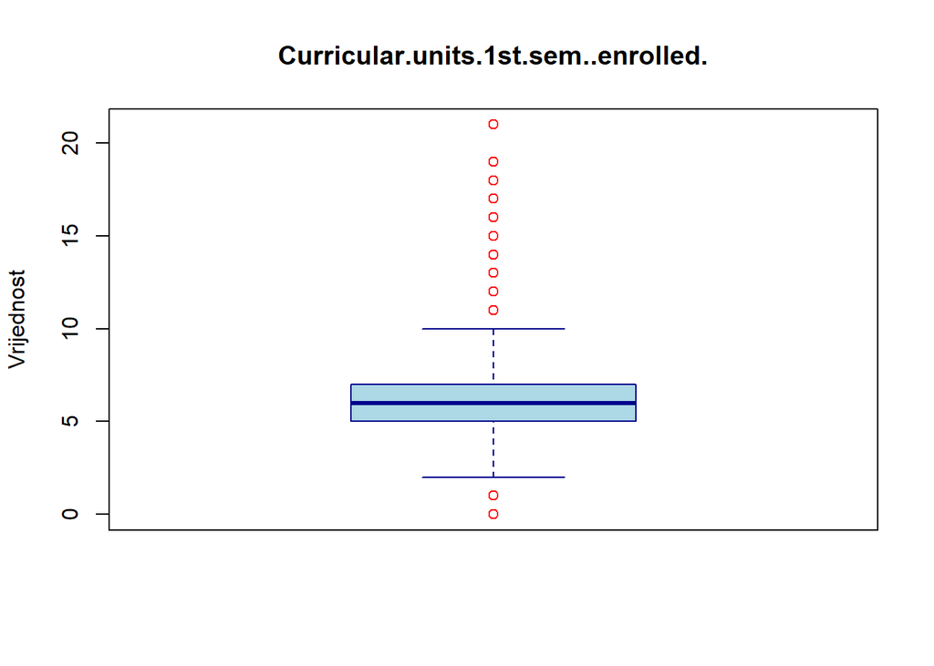

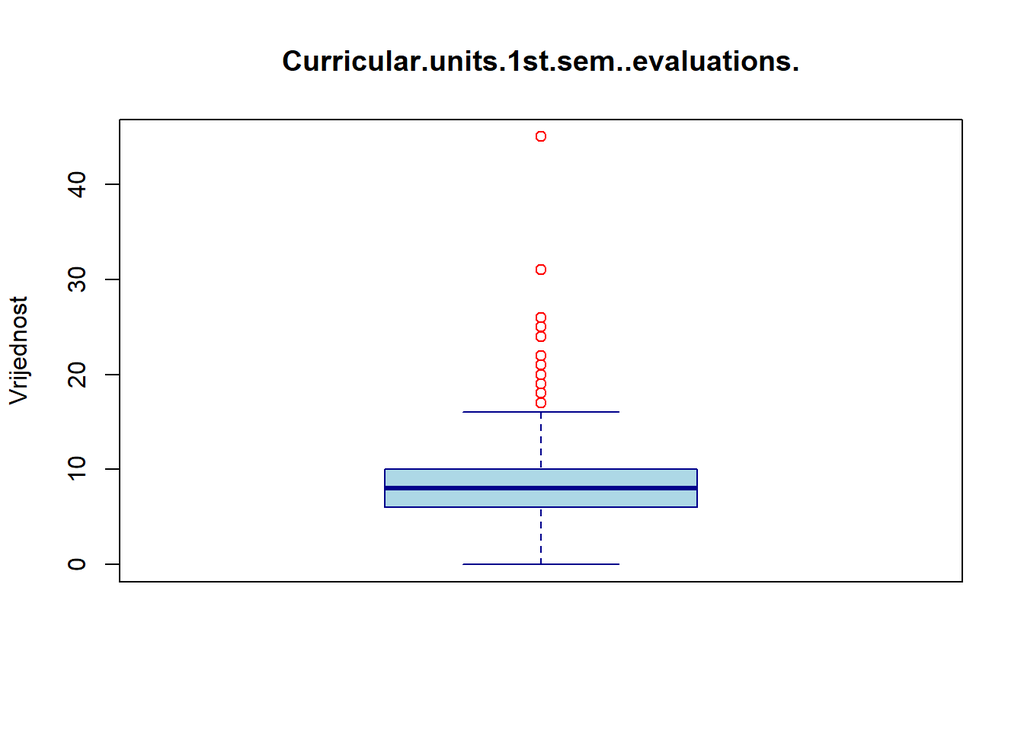

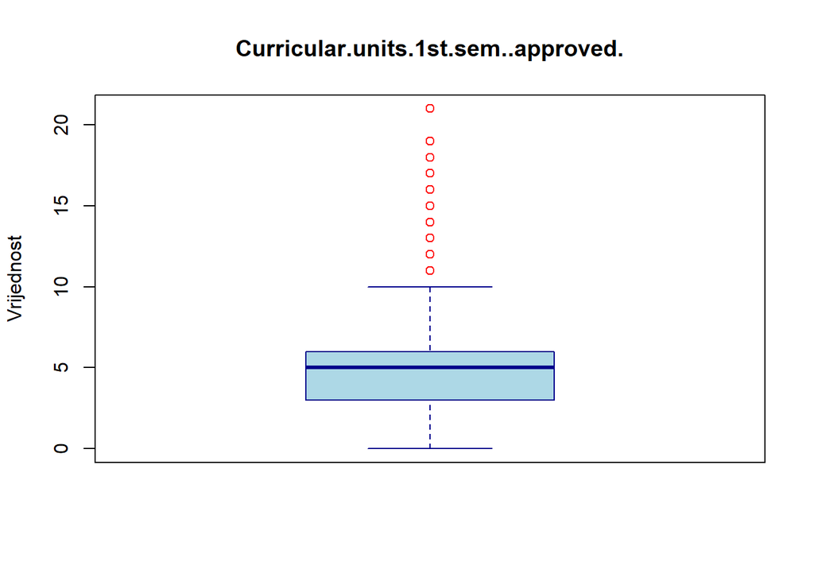

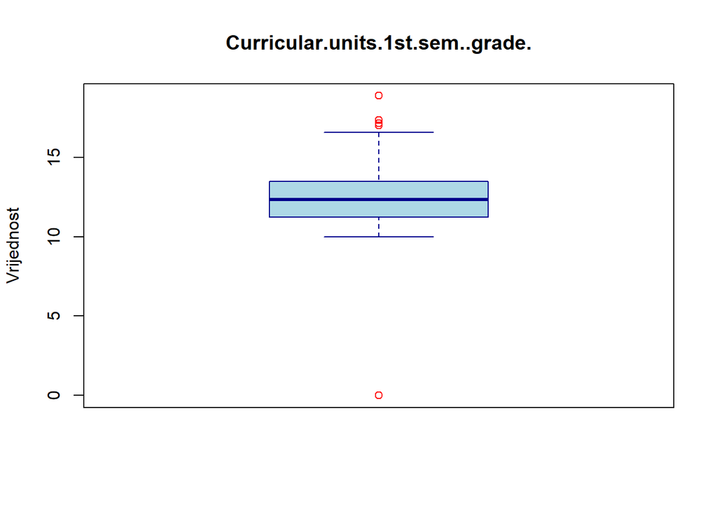

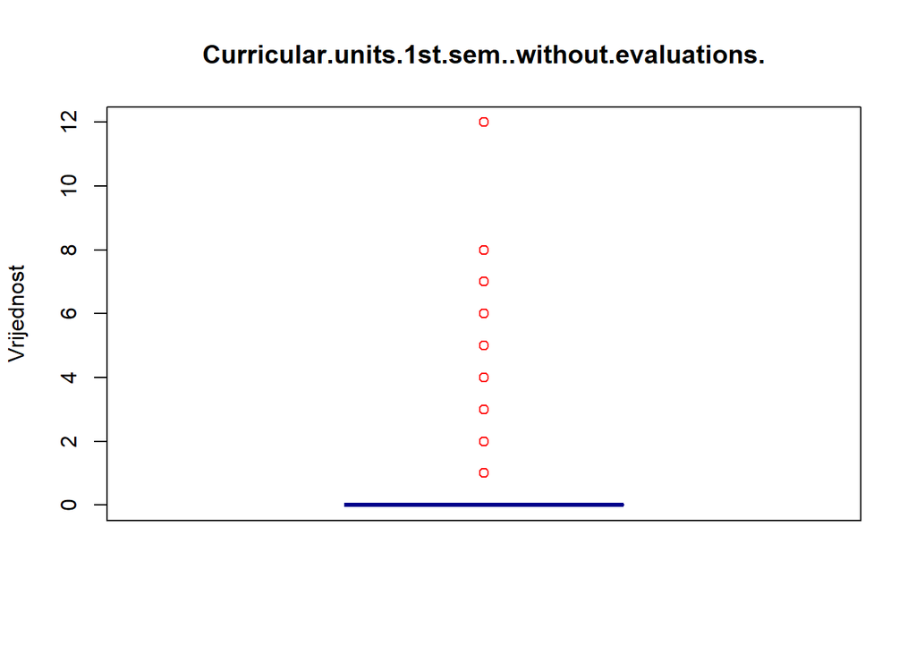

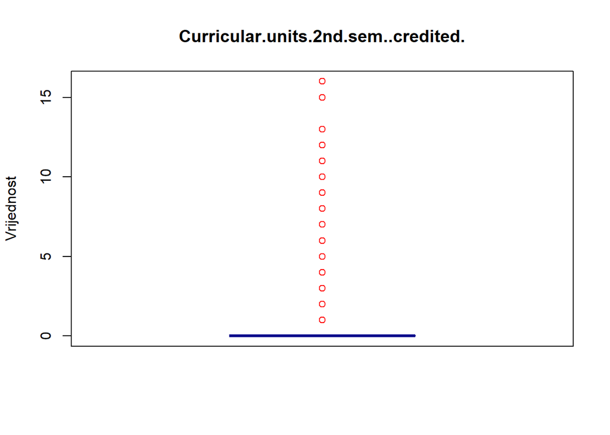

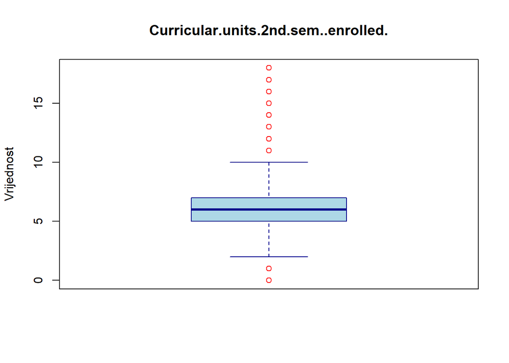

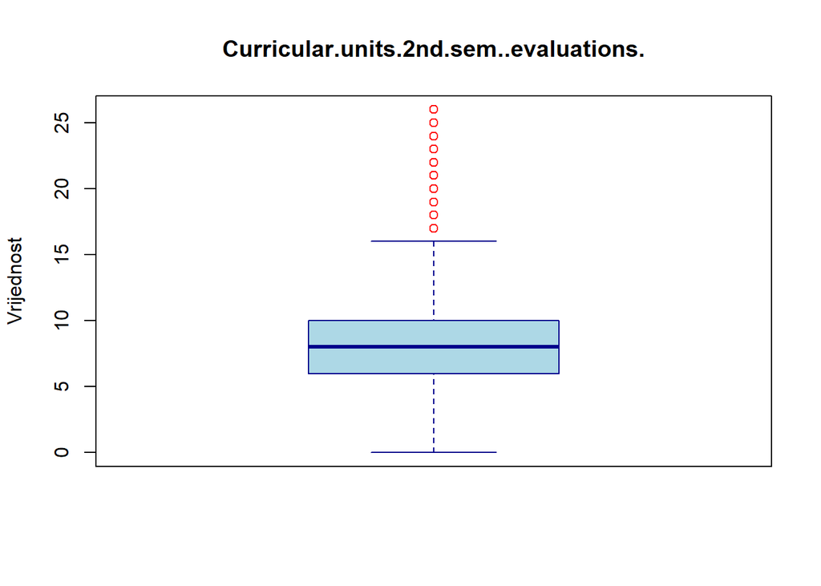

[6 more figures not shown]

```r
# Petlja za crtanje boxplotova za sve kvantitativne varijable
par(mfrow = c(1, 1))
for (var in kvantitativne) {
  boxplot(df_sample[[var]],
          main = var,
          ylab = "Vrijednost",
          col = "lightblue",
          border = "darkblue",
          outcol = "red")
}
```

```r
par(mfrow = c(1, 1))
```

Identificirani su outlieri u više numeričkih varijabli (npr. Admission.grade, Age.at.enrollment, Curricular.units…). Većina ekstremnih vrijednosti predstavlja realne, ali rijetke slučajeve (npr. studenti stariji od 60 godina, studenti s ocjenom 0 ili 20).

#### Postupanje:

Ako je vrijednost semantički opravdana i odražava stvarni slučaj onda se zadržava u skupu.

Ako je vrijednost statistički ekstremna i nelogična (npr. broj evaluacija je veći od normalnog raspona) onda se označava za dodatnu analizu i moguće uklanjanje.

Ako se outlier nalazi u binarnoj varijabli, zadržava se, jer doprinosi klasifikacijskim analizama.

#2. faza

# Odabir metoda

### Hi-kvadart test

U ovom testu provjeravamo postoji li statistički značajna povezanost između varijable Target (Dropout / Enrolled / Graduate) i Gender odnosno spola. Određene su nulta hipoteza i alternativna hipoteza te su navedene u analizi hi-kvadra testa ispod.

Nulta hipoteza: Varijable su nezavisne, tj. spol nije povezan s ishodom studiranja.

Alternativna hipoteza: Postoji povezanost između spola i ishoda studiranja.

```r
chisq_table <- table(df$Target, df$Gender)
chisq.test(chisq_table)
```

```
##
##  Pearson's Chi-squared test
##
## data:  chisq_table
## X-squared = 233.27, df = 2, p-value < 2.2e-16
```

Dobiveni rezultat: χ² (2) = 233.27. p < 2.2e-16 čime se snažno odbacuje nulta hipoteza.

Postoji statistički značajna povezanost između spola i ishoda studiranja (Target). To znači da je spol relevantan čimbenik u kontekstu odustajanja, diplomiranja ili nastavka studija. Ovaj rezultat je u skladu s kasnijim rezultatima logističke regresije, gdje je Gender također bio značajan prediktor te je to objašnjeno kasnije kroz rad.

###Provjera uvjeta za ANOVA analizu

```r
# Provjera normalnosti za svaku grupu Target
by(df$`Curricular.units.2nd.sem..grade.`, df$Target, shapiro.test)
```

```
## df$Target: Dropout
##
##  Shapiro-Wilk normality test
##
## data:  dd[x, ]
## W = 0.72922, p-value < 2.2e-16
##
## ------------------------------------------------------------
## df$Target: Enrolled
##
##  Shapiro-Wilk normality test
##
## data:  dd[x, ]
## W = 0.6324, p-value < 2.2e-16
##
## ------------------------------------------------------------
## df$Target: Graduate
##
##  Shapiro-Wilk normality test
##
## data:  dd[x, ]
## W = 0.62111, p-value < 2.2e-16
```

Sve tri grupe značajno odstupaju od normalne distribucije, jer je p < 0.05 u svakom slučaju te samim time normalnost nije zadovoljena.

```r
# Leveneov test
library(car)
leveneTest(Curricular.units.2nd.sem..grade. ~ Target, data = df)
```

|  | Df | F value | Pr(>F) |
| --- | --- | --- | --- |
| group | 2 | 557.2669 | 1.475784e-216 |
|  | 4421 | NA | NA |

Test je značajan što znači da se varijance među grupama značajno razlikuju pa homogenost nije zadovoljena.

Preduvjeti za ANOVA nisu ispunjeni. Budući da su oba ključna preduvjeta pala (normalnost i homogenost varijanci), ne smije se koristiti klasična ANOVA te se treba koristiti neparametarski Kruskal-Wallis test jer omogućuje usporedbu više grupa, nema pretpostavku o normalnosti te ne zahtijeva homogenost varijanci.

```r
kruskal.test(Curricular.units.2nd.sem..grade. ~ Target, data = df)
```

```
##
##  Kruskal-Wallis rank sum test
##
## data:  Curricular.units.2nd.sem..grade. by Target
## Kruskal-Wallis chi-squared = 1390.7, df = 2, p-value < 2.2e-16
```

Kruskal-Wallis test rezultati govore da je H vrijednost (Kruskal-Wallis chi-squared): 1390.7, stupnjevi slobode (df): 2, a p-vrijednost: < 2.2e-16 što vodi do zaključka da možemo odbaciti nultu hipotezu budući da je p < 0.05.

Nulta hipoteza: Nema razlike u raspodjeli ocjena u 2. semestru (Curricular.units.2nd.sem..grade.) između grupa (Dropout, Enrolled, Graduate). Alternativna hipoteza: Postoji razlika u barem jednoj grupi.

Dakle, studentske ocjene u 2. semestru se statistički značajno razlikuju ovisno o ishodu (Target).

```r
# install.packages("FSA")
```

```r
library(FSA)
dunnTest(Curricular.units.2nd.sem..grade. ~ Target, data = df, method = "bonferroni")
```

```
## Dunn (1964) Kruskal-Wallis multiple comparison
```

```
##   p-values adjusted with the Bonferroni method.
```

```
##            Comparison         Z       P.unadj         P.adj
## 1  Dropout - Enrolled -14.00223  1.510570e-44  4.531711e-44
## 2  Dropout - Graduate -37.10226 2.583097e-301 7.749290e-301
## 3 Enrolled - Graduate -15.49859  3.545880e-54  1.063764e-53
```

Post-hoc testom se određuju razlike između grupa te je zato proveden. Sve usporedbe su statistički značajne (p.adj < 0.05) što znači da studenti koji su odustali se značajno razlikuju po ocjenama u 2. semestru i od upisanih i od diplomiranih. Također postoji značajna razlika između upisanih i diplomiranih. Interpretacija po usporedbi: Dropout vs Enrolled: Odustali studenti imaju značajno niže ocjene od onih koji su još upisani. Dropout vs Graduate: Odustali studenti imaju daleko niže ocjene u odnosu na diplomirane – ova razlika je ekstremno značajna. Enrolled vs Graduate: I među onima koji su još upisani i onima koji su diplomirali postoji značajna razlika – diplomirani imaju više ocjene.

Ocjene u drugom semestru snažno su povezane s ishodom studija. Ta varijabla je statistički značajna u Kruskal-Wallis testu, a sve međusobne razlike su potvrđene Dunnovim testom što daje jako dobru osnovu za uključivanje ove varijable u regresijske modele kroz ovaj rad.

Također bi onda trebalo provjeriti da nema kolinearnih prediktora u regresiji

### Korelacijska matrica i dijagrami rasipanja

# Odabir numeričkih varijabli za korelaciju

```r
##num_vars <- df %>% select_if(is.numeric)
num_vars <- df_sample[, kvantitativne] #već napravljeno kao df_kv ali eto da se vidi opet...
```

Analiza: U ovom koraku izdvajamo samo kvantitativne (numeričke) varijable iz skupa podataka. To je važno jer korelacijska analiza ima smisla samo za numeričke varijable. Time osiguravamo da u daljnjim analizama ne uključujemo kvalitativne (kategorijske) podatke koji bi mogli iskriviti rezultate.

# Korelacijska matrica

```r
cor_matrix <- cor(num_vars, use = "complete.obs")
round(cor_matrix, 2)
```

```
##                                                Previous.qualification..grade.
## Previous.qualification..grade.                                           1.00
## Admission.grade                                                          0.58
## Age.at.enrollment                                                       -0.13
## Curricular.units.1st.sem..credited.                                     -0.01
## Curricular.units.1st.sem..enrolled.                                     -0.02
## Curricular.units.1st.sem..evaluations.                                  -0.09
## Curricular.units.1st.sem..approved.                                      0.05
## Curricular.units.1st.sem..grade.                                         0.05
## Curricular.units.1st.sem..without.evaluations.                          -0.03
## Curricular.units.2nd.sem..credited.                                     -0.02
## Curricular.units.2nd.sem..enrolled.                                     -0.02
## Curricular.units.2nd.sem..evaluations.                                  -0.06
## Curricular.units.2nd.sem..approved.                                      0.06
## Curricular.units.2nd.sem..grade.                                         0.08
## Curricular.units.2nd.sem..without.evaluations.                          -0.03
## Unemployment.rate                                                        0.03
## Inflation.rate                                                           0.00
## GDP                                                                     -0.03
##                                                Admission.grade
## Previous.qualification..grade.                            0.58
## Admission.grade                                           1.00
## Age.at.enrollment                                        -0.01
## Curricular.units.1st.sem..credited.                       0.06
## Curricular.units.1st.sem..enrolled.                      -0.01
## Curricular.units.1st.sem..evaluations.                   -0.07
## Curricular.units.1st.sem..approved.                       0.08
## Curricular.units.1st.sem..grade.                          0.07
## Curricular.units.1st.sem..without.evaluations.           -0.01
## Curricular.units.2nd.sem..credited.                       0.05
## Curricular.units.2nd.sem..enrolled.                      -0.03
## Curricular.units.2nd.sem..evaluations.                   -0.05
## Curricular.units.2nd.sem..approved.                       0.09
## Curricular.units.2nd.sem..grade.                          0.08
## Curricular.units.2nd.sem..without.evaluations.           -0.01
## Unemployment.rate                                         0.03
## Inflation.rate                                           -0.02
## GDP                                                      -0.05
##                                                Age.at.enrollment
## Previous.qualification..grade.                             -0.13
```

[output cut: 268 more lines]

```
## Curricular.units.1st.sem..credited.            -0.01
## Curricular.units.1st.sem..enrolled.            -0.01
## Curricular.units.1st.sem..evaluations.         -0.09
## Curricular.units.1st.sem..approved.             0.02
## Curricular.units.1st.sem..grade.                0.02
## Curricular.units.1st.sem..without.evaluations. -0.14
## Curricular.units.2nd.sem..credited.            -0.01
## Curricular.units.2nd.sem..enrolled.             0.00
## Curricular.units.2nd.sem..evaluations.          0.00
## Curricular.units.2nd.sem..approved.             0.02
## Curricular.units.2nd.sem..grade.                0.06
## Curricular.units.2nd.sem..without.evaluations. -0.11
## Unemployment.rate                              -0.34
## Inflation.rate                                 -0.11
## GDP                                             1.00
```

Analiza: Korelacijska matrica prikazuje međusobne linearne odnose između svih numeričkih varijabli. Vrijednosti blizu 1 ili -1 ukazuju na snažnu pozitivnu ili negativnu korelaciju, dok vrijednosti blizu 0 ukazuju na slab ili nikakav linearni odnos. Ova analiza pomaže identificirati varijable koje su međusobno povezane, što može biti korisno za odabir prediktora u daljnjim modelima.

# Vizualizacija korelacijske matrice (već postoji ranije u radu veća verzija)

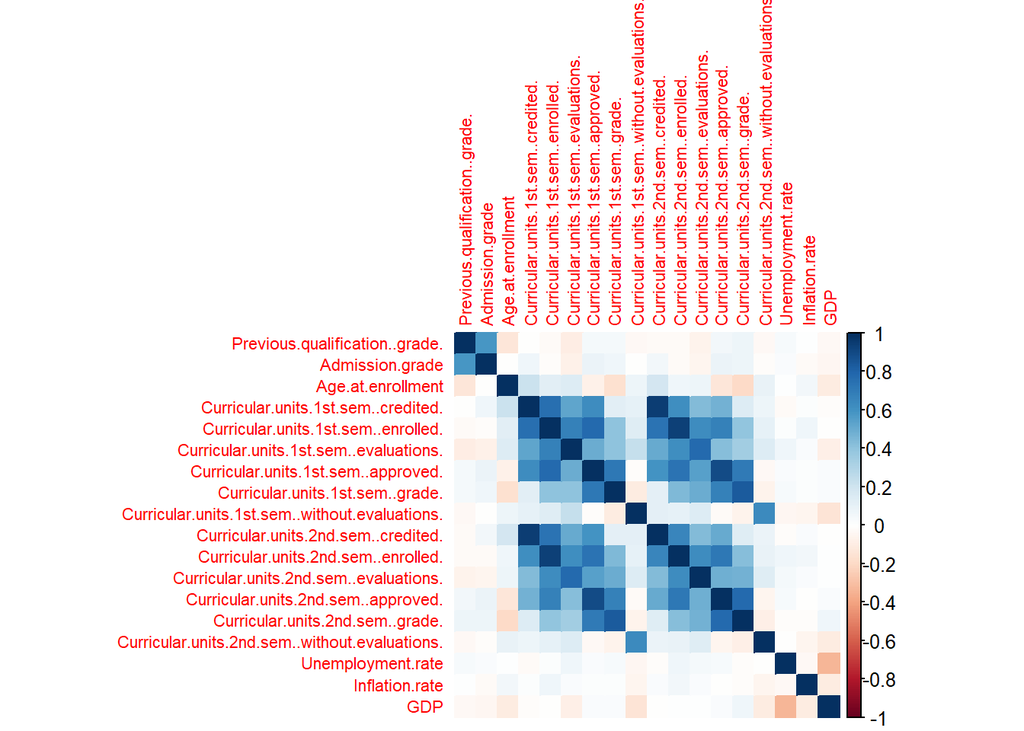

```r
library(corrplot)
corrplot::corrplot(cor_matrix, method = "color", tl.cex = 0.7)
```

Analiza: Vizualizacija korelacijske matrice pomoću ‘corrplot’ funkcije omogućuje brzu identifikaciju snažnih i slabih korelacija između varijabli. Boje i intenzitet kvadrata olakšavaju uočavanje obrazaca i potencijalnih problema s više kolinearnošću, što je važno za kasnije modeliranje.

# Dijagrami rasipanja za najvažnije varijable

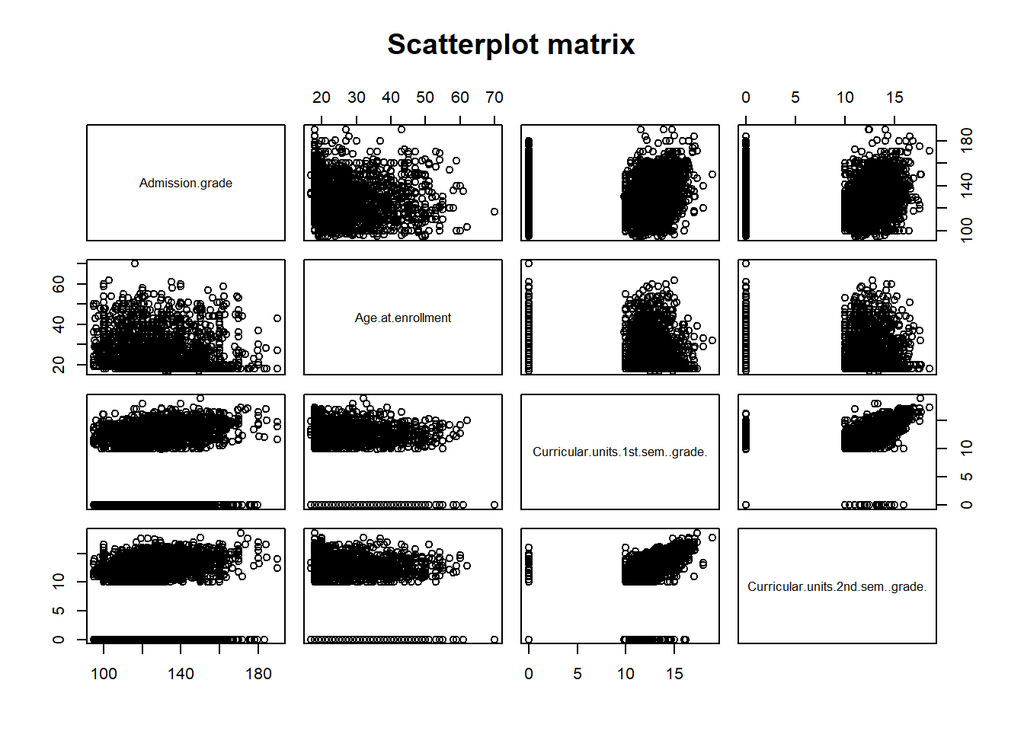

```r
pairs(~ Admission.grade + Age.at.enrollment + Curricular.units.1st.sem..grade. + Curricular.units.2nd.sem..grade., data = df, main = "Scatterplot matrix")
```

Analiza: Dijagrami rasipanja (scatterplot matrix) omogućuju vizualnu procjenu odnosa između parova najvažnijih varijabli. Ovdje možemo uočiti postoji li linearna ili nelinearna veza, te identificirati eventualne outliere ili obrasce koji bi mogli utjecati na rezultate regresije.

### Priprema podataka za logističku regresiju

```r
# Smanjujemo Target na dvije klase: Dropout vs. ostali (Graduate/Enrolled)
df$Dropout <- ifelse(df$Target == "Dropout", 1, 0)

table(df$Dropout)
```

```
##
##    0    1
## 3003 1421
```

```r
prop.table(table(df$Dropout)) * 100
```

```
##
##        0        1
## 67.87975 32.12025
```

Analiza: Ovdje redefiniramo ciljnu varijablu tako da imamo binarnu klasifikaciju: 1 označava studente koji su odustali, a 0 one koji su diplomirali ili su još upisani. Time pojednostavljujemo problem i omogućujemo primjenu logističke regresije. Tablica prikazuje distribuciju klasa, što je važno za procjenu uravnoteženosti skupa podataka. Ova distribucija pokazuje da je skup podataka umjereno neuravnotežen, s većim brojem studenata koji nisu odustali (~ 68%). Unatoč neuravnoteženosti, omjer klasa je dovoljno dobar za pouzdano treniranje logističkog modela bez potrebe za dodatnim tehnikama balansiranja.

# Odabir prediktora na temelju korelacija i domene

```r
model_data <- df %>% select(Dropout, Admission.grade, Age.at.enrollment, Gender, Curricular.units.1st.sem..grade., Curricular.units.2nd.sem..grade.)
model_data <- na.omit(model_data)
```

Analiza: Za modeliranje biramo varijable koje su prema korelacijskoj analizi i stručnoj procjeni najrelevantnije za predviđanje odustajanja. Uklanjanjem redaka s nedostajućim vrijednostima (na.omit) osiguravamo da model ne bude pristran zbog nepotpunih podataka. Odabrane varijable uključuju ocjenu pri upisu (Admission.grade), dob pri upisu (Age.at.enrollment), spol (Gender) te prosječne ocjene iz prvog i drugog semestra. Ove varijable su identificirane kao relevantne kroz kombinaciju domenskog znanja i rezultata korelacijske matrice. Korištenjem ovih prediktora model ima potencijal prepoznati obrazovne i demografske obrasce koji ukazuju na povećani rizik od odustajanja.

### Logistička regresija

```r
model <- glm(Dropout ~ ., data = model_data, family = binomial)
summary(model)
```

```
##
## Call:
## glm(formula = Dropout ~ ., family = binomial, data = model_data)
##
## Coefficients:
##                                   Estimate Std. Error z value Pr(>|z|)
## (Intercept)                       1.915429   0.392702   4.878 1.07e-06 ***
## Admission.grade                  -0.014523   0.002827  -5.138 2.78e-07 ***
## Age.at.enrollment                 0.057579   0.005007  11.500  < 2e-16 ***
## Gender                            0.529910   0.083004   6.384 1.72e-10 ***
## Curricular.units.1st.sem..grade.  0.006812   0.015762   0.432    0.666
## Curricular.units.2nd.sem..grade. -0.251067   0.014974 -16.767  < 2e-16 ***
## ---
## Signif. codes:  0 '***' 0.001 '**' 0.01 '*' 0.05 '.' 0.1 ' ' 1
##
## (Dispersion parameter for binomial family taken to be 1)
##
##     Null deviance: 5554.5  on 4423  degrees of freedom
## Residual deviance: 3909.3  on 4418  degrees of freedom
## AIC: 3921.3
##
## Number of Fisher Scoring iterations: 4
```

```r
# Predikcija
model_data$pred <- predict(model, type = "response")

# Ukloni NA ako ih ima
model_data <- model_data[complete.cases(model_data$Dropout, model_data$pred), ]

# Izračunaj ROC
library(pROC)
roc_obj <- roc(model_data$Dropout, model_data$pred)
```

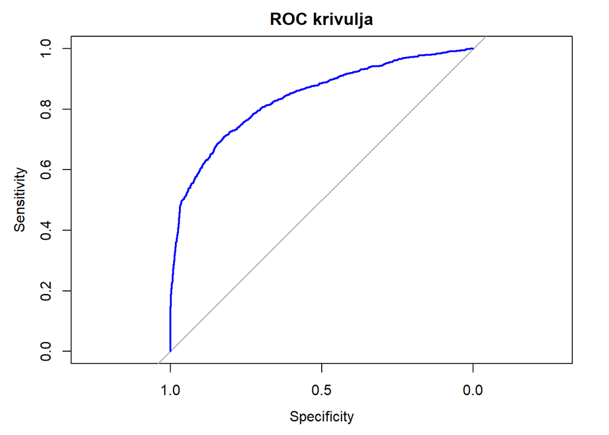

```r
plot(roc_obj, col = "blue", main = "ROC krivulja")
```

```r
auc(roc_obj)
```

```
## Area under the curve: 0.8371
```

Analiza: Za potrebe regresijske analize, odabrana je varijabla Target kao zavisna varijabla. Budući da se radi o kvalitativnoj varijabli s tri razine (Dropout, Enrolled, Graduate), za binarnu logističku regresiju transformirana je u novu varijablu Dropout (1 = Dropout, 0 = ostali). Time se omogućava modeliranje vjerojatnosti odustajanja studenata u odnosu na sve ostale ishode. Logistička regresija modelira vjerojatnost odustajanja na temelju odabranih prediktora. Izlaz summary(model) daje procjene koeficijenata, njihove standardne pogreške, z-vrijednosti i p-vrijednosti. Koeficijenti pokazuju smjer i snagu utjecaja svake varijable na vjerojatnost odustajanja. P-vrijednosti nam govore koje su varijable statistički značajne.

ROC krivulja prikazuje kompromis između osjetljivosti (sensitivity) i specifičnosti (specificity) klasifikacijskog modela. AUC (Area Under the Curve) predstavlja ukupnu sposobnost modela da ispravno klasificira primjere: vrijednosti blizu 1 ukazuju na izvrstan model, dok vrijednosti blizu 0.5 ukazuju na nasumično pogađanje. U našem slučaju, AUC = 0.8371, što ukazuje na vrlo dobru (>0.8) klasifikacijsku sposobnost. Takav rezultat sugerira da model može služiti kao koristan alat za prepoznavanje rizičnih studenata prije nego odustanu.

# Izračun omjera izgleda (odds ratio)

```r
exp(coef(model))
```

```
##                      (Intercept)                  Admission.grade
##                        6.7898540                        0.9855816
##                Age.at.enrollment                           Gender
##                        1.0592690                        1.6987795
## Curricular.units.1st.sem..grade. Curricular.units.2nd.sem..grade.
##                        1.0068352                        0.7779701
```

Analiza: Omjeri izgleda (odds ratio) interpretiraju se kao promjena u omjeru vjerojatnosti odustajanja za jedinicu promjene prediktora. Vrijednosti veće od 1 ukazuju na povećanje rizika od odustajanja, dok vrijednosti manje od 1 ukazuju na smanjenje rizika.

Admission.grade (omjer izgleda ~ 0.99): za svaku jedinicu veću ocjenu pri upisu, vjerojatnost odustajanja se smanjuje za otprilike 1% (jer je omjer izgleda < 1). Pokazuje da su bolji kandidati manje skloni odustajanju.

Age.at.enrollment (omjer izgleda ~ 1.06): stariji studenti imaju 6% veću šansu za odustajanje po svakoj godini starosti. Može ukazivati na dodatne životne obaveze (posao, obitelj).

Gender (omjer izgleda ~ 1.70): ovisno o kodiranju, jedna skupina (najčešće muškarci ako je muški = 1) ima 70% veću šansu za odustajanje. Važno je jasno specificirati kodiranje varijable Gender u dokumentaciji.

Curricular.units.1st.sem..grade. (omjer izgleda ~ 1.007): efekt je vrlo blizu 1 i nije statistički značajan (p-vrijednost), što sugerira da ocjene u 1. semestru ne pridonose značajno modelu kada su druge varijable prisutne.

Curricular.units.2nd.sem..grade. (omjer izgleda ~ 0.78): bolji uspjeh u drugom semestru smanjuje rizik od odustajanja za 22% po jedinici ocjene. Ovo je snažan i značajan zaštitni faktor.

Interpretacija omjera izgleda omogućuje kvantificiranje efekta svake varijable na ishod. U kontekstu obrazovne politike, rezultati sugeriraju da akademski uspjeh i pripremljenost pri upisu (Admission.grade, 2nd.sem.grade) igraju ključnu ulogu, dok demografski faktori (dob, spol) također nose značajnu težinu.

# Signifikantnost modela

```r
anova(model, test = "Chisq")
```

|  | Df | Deviance | Resid. Df | Resid. Dev | Pr(>Chi) |
| --- | --- | --- | --- | --- | --- |
| NULL | NA | NA | 4423 | 5554.532 | NA |
| Admission.grade | 1 | 41.36721 | 4422 | 5513.164 | 1.261557e-10 |
| Age.at.enrollment | 1 | 267.01329 | 4421 | 5246.151 | 5.079999e-60 |
| Gender | 1 | 133.96371 | 4420 | 5112.188 | 5.564323e-31 |
| Curricular.units.1st.sem..grade. | 1 | 803.56472 | 4419 | 4308.623 | 9.057933e-177 |
| Curricular.units.2nd.sem..grade. | 1 | 399.31627 | 4418 | 3909.307 | 7.758426e-89 |

Analiza: ANOVA tablica s Chi-kvadrat testiranjem (tipična za generalizirane linearne modele) prikazuje sekvencijalni doprinos svake varijable smanjenju devijance modela. Devijanca je mjera “pogreške” modela – niža vrijednost devijance znači bolju prilagodbu podacima.

Za svaki prediktor navodi se: Df - broj stupnjeva slobode (1 po varijabli) Deviance - koliki doprinos ima ta varijabla u smanjenju ukupne devijance modela Pr(>Chi) - p-vrijednost za testiranje hipoteze da varijabla ne doprinosi značajno

Tumačenje po varijabli: Admission.grade (p ~ 1.3e-10) - značajno doprinosi: što je viša ulazna ocjena, manja je šansa za odustajanje. Age.at.enrollment (p < 2.2e-16) - iznimno značajan prediktor: dob ima snažnu povezanost s ishodom. Gender (p < 2.2e-16) - spol također statistički značajno utječe na ishod. Curricular.units.1st.sem..grade. (p < 2.2e-16) - ovdje pokazuje jako veliki doprinos modelu. Curricular.units.2nd.sem..grade. (p < 2.2e-16) - jasno značajna varijabla s velikim doprinosom modelu.

# Predikcija i evaluacija modela

```r
model_data$pred <- predict(model, type = "response")
model_data$pred_class <- ifelse(model_data$pred > 0.5, 1, 0)

table(Predicted = model_data$pred_class, Actual = model_data$Dropout)
```

```
##          Actual
## Predicted    0    1
##         0 2806  649
##         1  197  772
```

Moguće evaluacijske metrike:

Model je relativno precizan u predviđanju odustajanja (visoka preciznost), ali ima umjeren odziv odnosno propustio je dio stvarno odustalih studenata. To može biti problem u praksi, jer studenti koji su stvarno u riziku možda neće biti prepoznati.

# Izračun točnosti

```r
model_data$pred <- predict(model, type = "response")
model_data$pred_class <- ifelse(model_data$pred > 0.5, 1, 0)
mean(model_data$pred_class == model_data$Dropout)
```

```
## [1] 0.8087703
```

Analiza: Točnost modela predstavlja udio ispravno klasificiranih slučajeva. (Točno klasificirano odustajanje i točno klasificirano “ostajanje” podijeljeno s ukupnim brojem promatranja) u ovom slučaju ~ 80.88%. Visoka točnost ukazuje na dobru prediktivnu sposobnost modela, ali treba biti oprezan kod neuravnoteženih klasa – tada je korisno dodatno analizirati metrike poput preciznosti, odziva i F1-mjere.

Preporučljivo je uključiti i : Preciznost (Precision): Koliko je točnih među onima za koje je model rekao da su odustali. Odziv (Recall): Koliki postotak stvarno odustalih studenata je model uspio otkriti. F1-mjeru: Harmoničnu sredinu preciznosti i odziva, koja posebno dolazi do izražaja kada su klase neuravnotežene.

```r
# install.packages("caret")
library(caret)
confusionMatrix(factor(model_data$pred_class), factor(model_data$Dropout), positive = "1")
```

```
## Confusion Matrix and Statistics
##
##           Reference
## Prediction    0    1
##          0 2806  649
##          1  197  772
##
##                Accuracy : 0.8088
##                  95% CI : (0.7969, 0.8203)
##     No Information Rate : 0.6788
##     P-Value [Acc > NIR] : < 2.2e-16
##
##                   Kappa : 0.5214
##
##  Mcnemar's Test P-Value : < 2.2e-16
##
##             Sensitivity : 0.5433
##             Specificity : 0.9344
##          Pos Pred Value : 0.7967
##          Neg Pred Value : 0.8122
##              Prevalence : 0.3212
##          Detection Rate : 0.1745
##    Detection Prevalence : 0.2190
##       Balanced Accuracy : 0.7388
##
##        'Positive' Class : 1
##
```

Analiza: Analiza rezultata proširene evaluacije modela binarne logističke regresije uključuje ključne klasifikacijske metrike koje nadopunjuju samu točnost i pružaju dublji uvid u učinkovitost modela, osobito u kontekstu neuravnoteženih klasa.

U cjelini, model pokazuje dobru klasifikacijsku sposobnost, ali postoji prostor za poboljšanja, osobito u pogledu osjetljivosti (odaziva), što je osobito važno ako je cilj proaktivna identifikacija ugroženih studenata.

### Interpretacija rezultata

Komentar: Prikazani su koeficijenti modela, njihova signifikantnost i omjeri izgleda. Važno je interpretirati koji prediktori značajno utječu na vjerojatnost odustajanja. Također, prikazana je točnost modela i matrica klasifikacije.

Preporuka: Analizirati rezidualne dijagnostičke grafove (plot(model)) i razmotriti dodatne varijable ili interakcije ako je potrebno.

### Rezultati binarne logističke regresije pokazuju:

Admission.grade: Negativan i signifikantan koeficijent (omjer izgleda ~ 0.99) upućuje da veća ocjena pri upisu smanjuje vjerojatnost odustajanja.

Age.at.enrollment: Pozitivan i signifikantan (omjer izgleda ~ 1.06) - stariji studenti češće odustaju.

Gender: Pozitivan i signifikantan (omjer izgleda ~ 1.70) → muškarci imaju veću šansu za odustajanje.

Curricular.units.2nd.sem..grade.: Negativan i snažno signifikantan (omjer izgleda ~ 0.78) - bolje ocjene u 2. semestru smanjuju rizik od odustajanja.

Curricular.units.1st.sem..grade.: Nije značajan – moguće je da varijabla ne doprinosi dodatno uz ostale prediktore.

### Literatura

1. R documentation: https://www.r-project.org/
2. Corrplot package: https://cran.r-project.org/web/packages/corrplot/
3. Literatura iz kolegija i znanstveni članci o studentskoj odustajnosti